# ggplot2 Elegant Graphics for Data Analysis

홍우헌

quasar103@naver.com

2018-06-25

> Chapter 8  
> Themes

테마 시스템은 4가지 주요소로 구성되어 있다:

- Theme elements는 non-data요소를 명시한다. 예를 들어, plot.title요소는 플랏의 제목을, axis.ticks.x는 x축의 눈금을, legend.key.height는 범례의 키의 높이이다.
- 각 성분은 element function와 연관되어 있고 이것은 성분의 시각적 요소를 설명한다. 예를 들어, element_text()는 plot.title같은 폰트 사이즈, 색, 글꼴을 설정한다.
- theme()함수는 디폴트 테마 요소를 element function을 호출함으로써 오버라이딩 한다. theme(plot.title = element_text(colour = “red”))
- 완성된 테마, theme_grey()

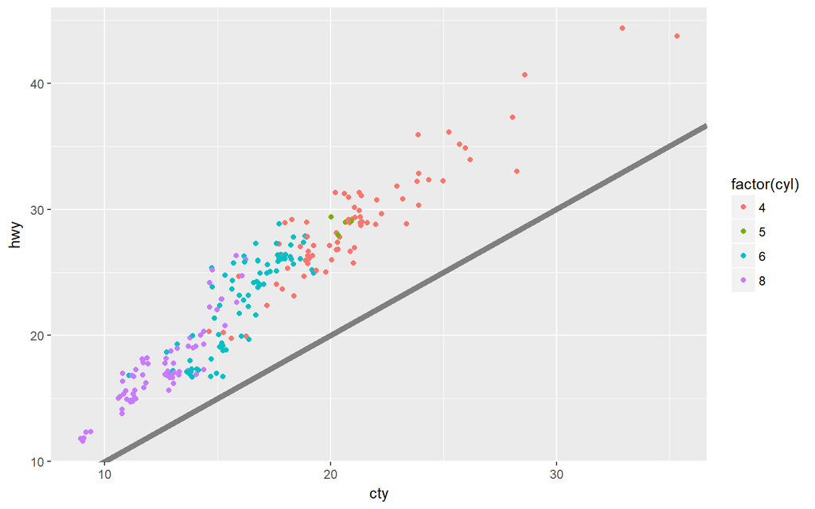

```r
base <- ggplot(mpg, aes(cty, hwy, color = factor(cyl))) +
  geom_jitter() +
  geom_abline(colour = "grey50", size = 2)
base
```

다른사람에게 플랏을 공유하거나 논문에 쓰려고 한다. 먼저,

- 축과 범례의 레이블을 개선한다.
- 플랏의 제목을 단다.
- 색을 조정한다.

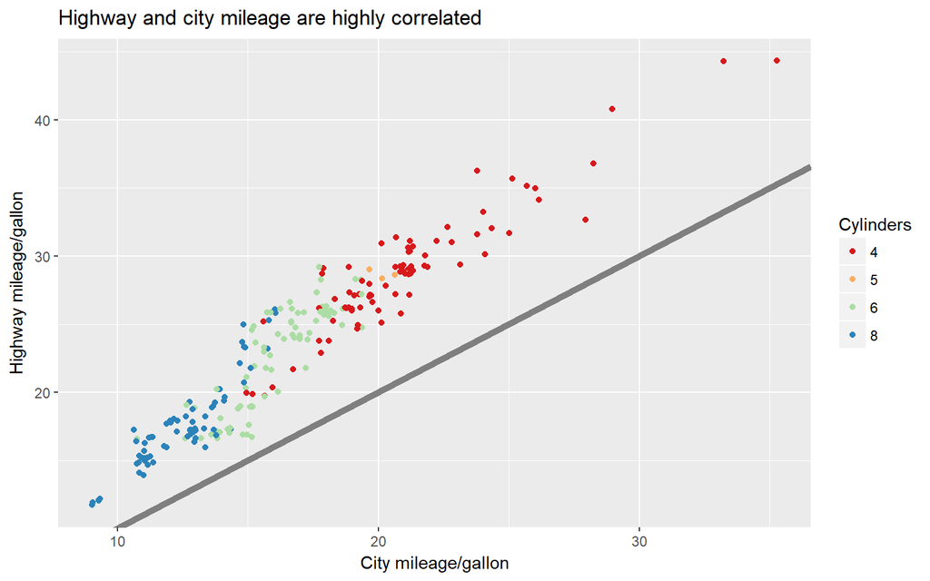

```r
labelled <- base +
  labs(
    x = "City mileage/gallon",
    y = "Highway mileage/gallon",
    colour = "Cylinders",
    title = "Highway and city mileage are highly correlated"
  ) +
  scale_colour_brewer(type = "seq", palette = "Spectral")
labelled
```

다음으로, 플랏이 style guidelines of journal에 매치되도록 한다.

- 배경색은 흰색이 되도록 하자.
- 범례는 공간이 있다면 플랏 내부에 위치 시키자
- 주요 가이드라인은 옅은 회색으로 부 가이드 라인은 제거한다.
- 플랏의 제목은 12pt bold text

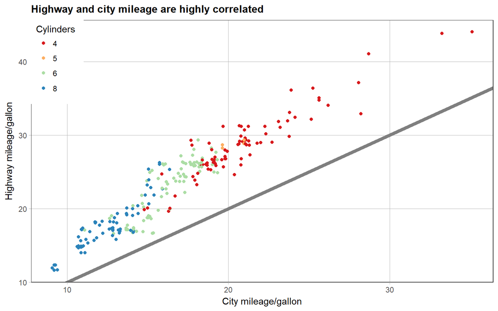

```r
styled <- labelled +
  theme_bw() +
  theme(
    plot.title = element_text(face = "bold", size = 12),
    legend.background = element_rect(fill = "white", size = 4, colour = "white"),
    legend.position = c(0, 1),
    legend.justification = c(0, 1), # 범례 왼쪽 위 모서리 위치 설정
    axis.ticks = element_line(colour = "grey70", size = 0.2),
    panel.grid.major = element_line(colour = "grey70", size = 0.1),
    panel.grid.minor = element_blank()
  )
styled
```

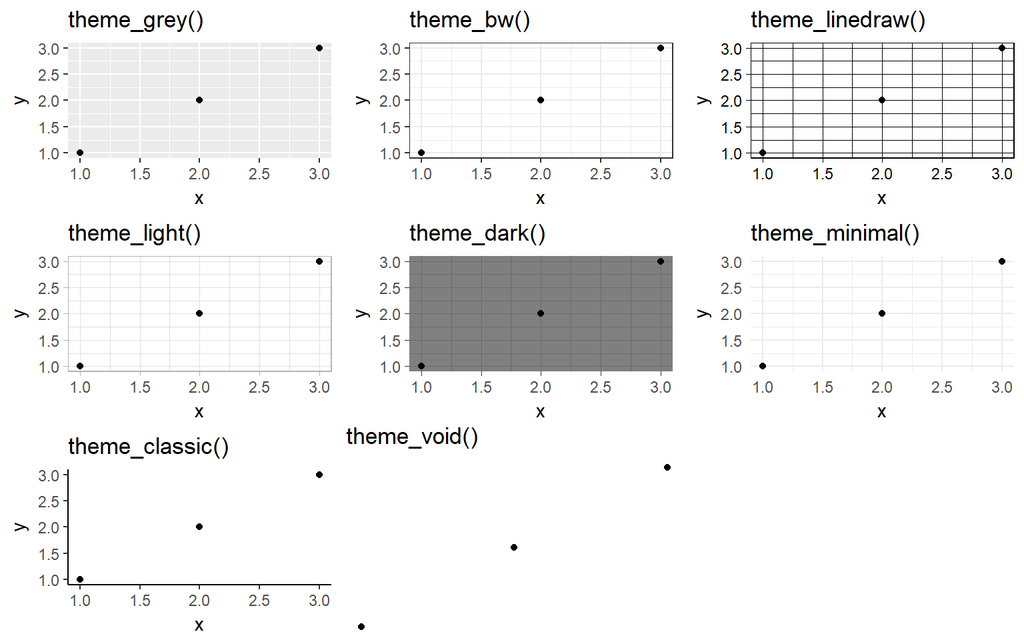

```r
df <- data.frame(x = 1:3, y = 1:3)
base <- ggplot(df, aes(x, y)) + geom_point()
grid.arrange(
base + theme_grey() + ggtitle("theme_grey()"),
base + theme_bw() + ggtitle("theme_bw()"),
base + theme_linedraw() + ggtitle("theme_linedraw()"),
base + theme_light() + ggtitle("theme_light()"),
base + theme_dark() + ggtitle("theme_dark()"),
base + theme_minimal() + ggtitle("theme_minimal()"),
base + theme_classic() + ggtitle("theme_classic()"),
base + theme_void() + ggtitle("theme_void()"), nrow = 3, ncol = 3)
```

`theme_set(theme_bw())` 와 같이 theme_set()을 사용하면 ggplot2의 디폴트 테마를 변경할 수 있다.

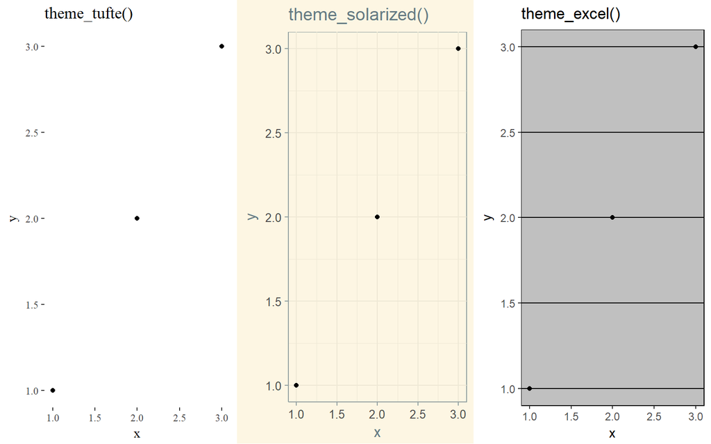

```r
library(ggthemes)
grid.arrange(
base + theme_tufte() + ggtitle("theme_tufte()"),
base + theme_solarized() + ggtitle("theme_solarized()"),
base + theme_excel() + ggtitle("theme_excel()"), ncol = 3)
```

## 0.1 Exercises

Try out all the themes in ggthemes. Which do you like the best?

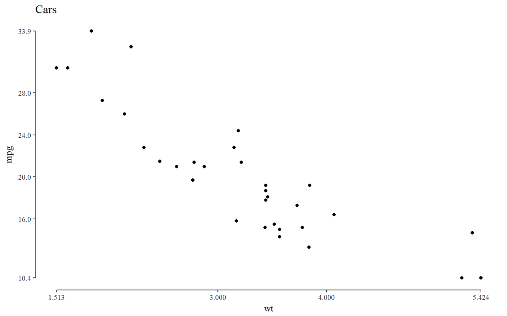

```r
p <- ggplot(mtcars, aes(x = wt, y = mpg)) +
    geom_point() +
    ggtitle("Cars")

p + geom_rangeframe() +
    theme_tufte() +
    scale_x_continuous(breaks = extended_range_breaks()(mtcars$wt)) + # 축의 구분을 변수의 범위로한다.
    scale_y_continuous(breaks = extended_range_breaks()(mtcars$mpg))
```

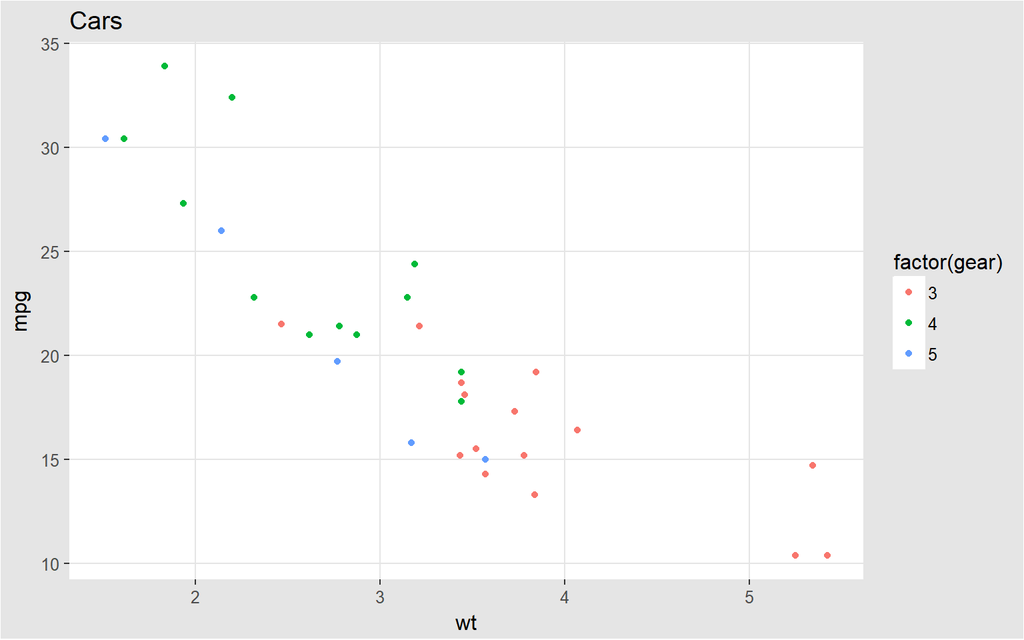

```r
p2 <- ggplot(mtcars, aes(x = wt, y = mpg, colour = factor(gear))) +
    geom_point() +
    ggtitle("Cars")

p2 + theme_igray() # 회색과 흰색을 inverse
```

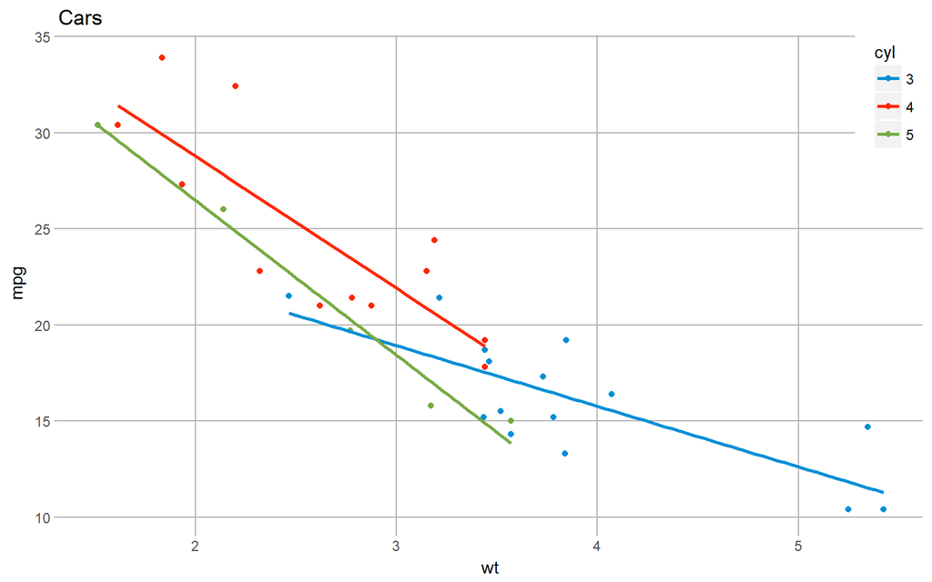

```r
p2 + geom_smooth(method = "lm", se = FALSE) +
    scale_color_fivethirtyeight("cyl") +
    theme(
          panel.background = element_rect(fill = "white"),
          axis.ticks = element_line(colour = "grey70"),
          panel.grid.major = element_line(colour = "grey70"),
          legend.background = element_rect(fill = "white", size = 6, colour = "white"),
          legend.justification = c(1, 1),
          legend.position = c(1, 1)
          )
```

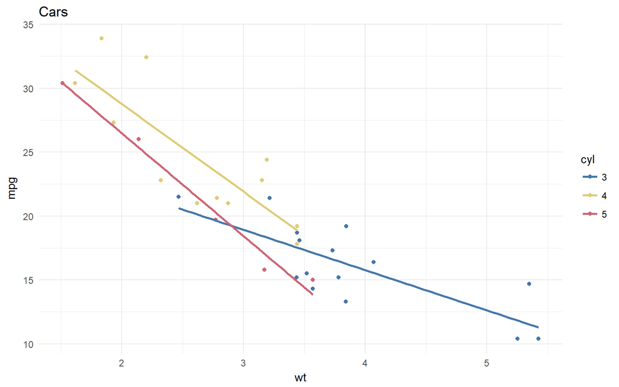

```r
p2 + geom_smooth(method = "lm", se = FALSE) +
    scale_color_ptol("cyl") +
    theme_minimal()
```

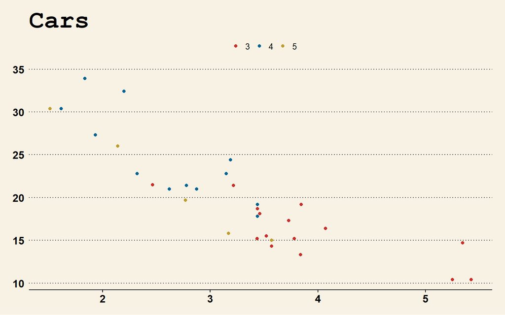

```r
p2 + theme_wsj() + scale_colour_wsj("colors6", "") # The Wall Street Journal.
```

```r
# 두 번째 인자를 설정해줘야한다.
```

# 1 Modifying Theme Components

테마의 성분을 수정하기 위해서 `plot + theme(element.name = element_function())과 같이 코드를 작성하라. 4가지 기본 타입의 built-in element functions이 있다. 각 element function은 외관을 통제할 매개변수의 집합을 가지고 있다.

- `element_text()`는 레이블과 headings를 그린다. 글꼴, 글자체 , 색상, 크기, hjust, vjust, angle and lineheight를 조절할 수 있다.

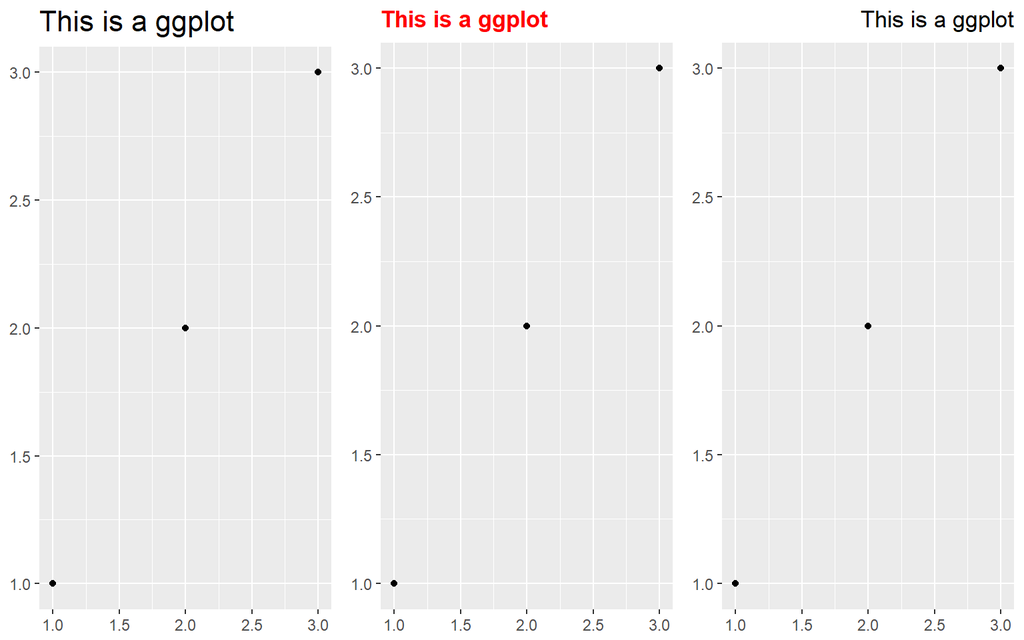

```r
base_t <- base + labs(title = "This is a ggplot") + xlab(NULL) + ylab(NULL)
grid.arrange(
base_t + theme(plot.title = element_text(size = 16)),
base_t + theme(plot.title = element_text(face = "bold", colour = "red")),
base_t + theme(plot.title = element_text(hjust = 1)), ncol = 3)
```

text는 또한 `margin`인자와 `margin()`함수를 가지고 있다. margin()는 네가지 인자를 가지고 있는데, top(t), right(r), bottom(b) and left(l) sides of the text.

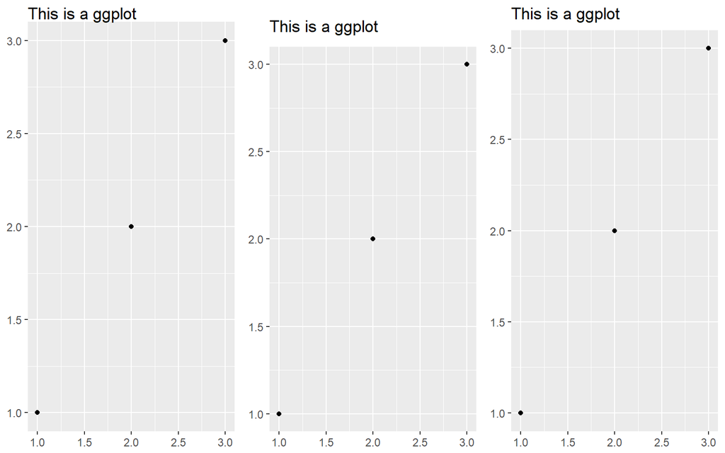

```r
# The margins here look asymmetric because there are also plot margins
grid.arrange(
base_t + theme(plot.title = element_text(margin = margin())), # 제목주변의 여백이 사라짐
base_t + theme(plot.title = element_text(margin = margin(t = 10, b = 10))), # 제목 위와 아래의 여백이 생김
base_t + theme(axis.title.y = element_text(margin = margin(r = 10))), ncol = 3)
```

- `element_line()`는 색, 사이즈, linetype를 조정해 선을 그린다.

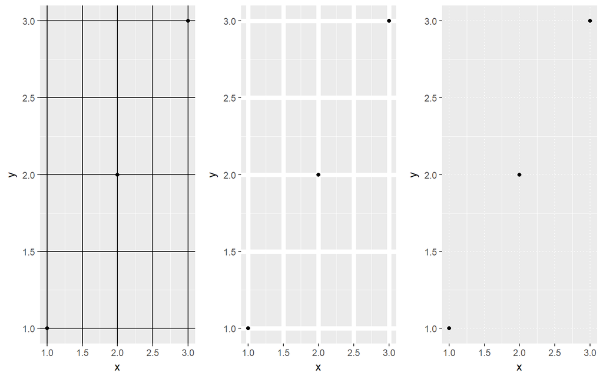

```r
grid.arrange(
  base + theme(panel.grid.major = element_line(colour = "black")),
  base + theme(panel.grid.major = element_line(size = 2)),
  base + theme(panel.grid.major = element_line(linetype = "dotted")), ncol = 3
)
```

- `element_rect()`는 사각형을 그린다. 대부분 배경에 이용되며 fill, colour and border colour, size and linetype 매개변수를 가지고 있다. plot과 panel차이 이해

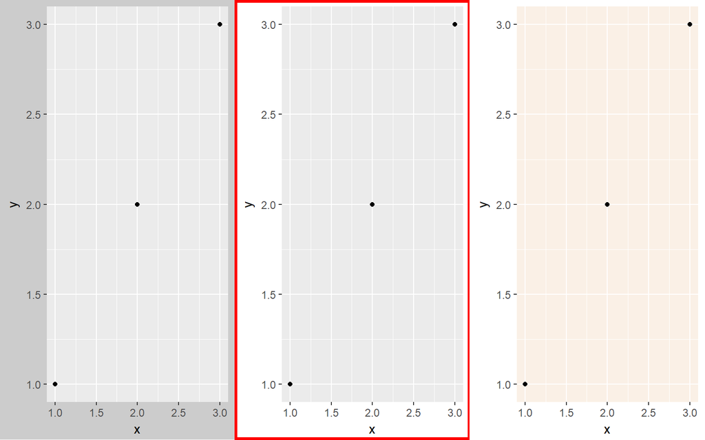

```r
grid.arrange(
base + theme(plot.background = element_rect(fill = "grey80", colour = NA)),
base + theme(plot.background = element_rect(colour = "red", size = 2)),
base + theme(panel.background = element_rect(fill = "linen")), ncol = 3)
```

- `element_blank()` 는 아무것도 그리지 않는다.

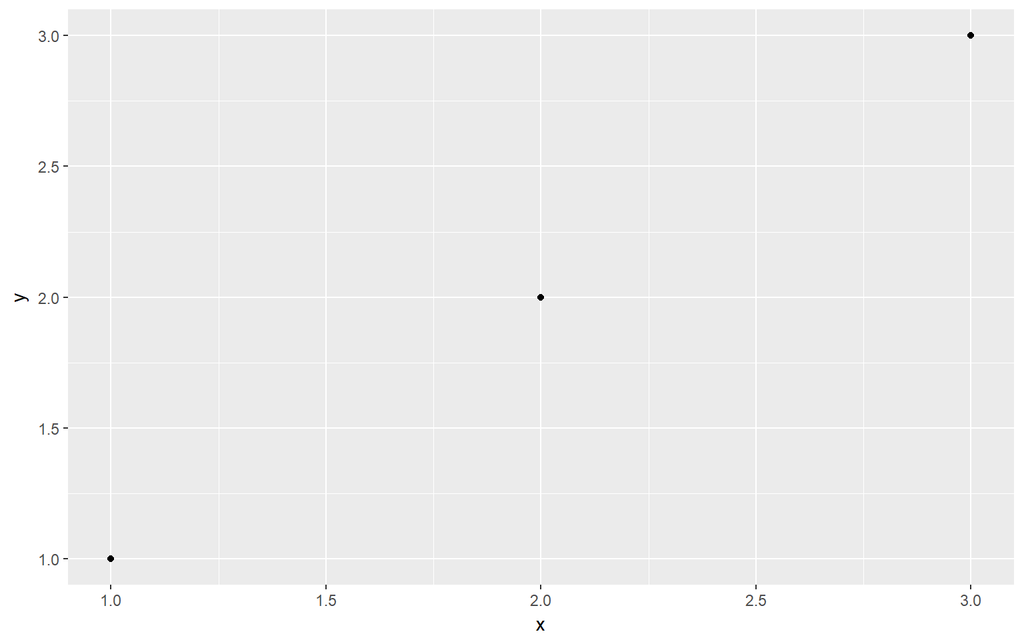

```r
base
```

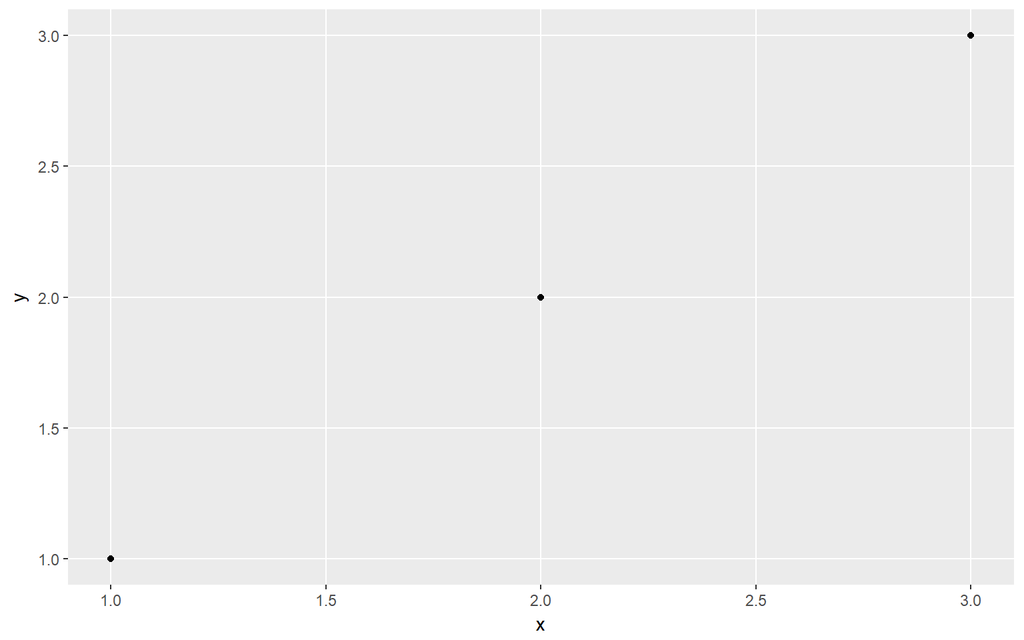

```r
last_plot() + theme(panel.grid.minor = element_blank())
```

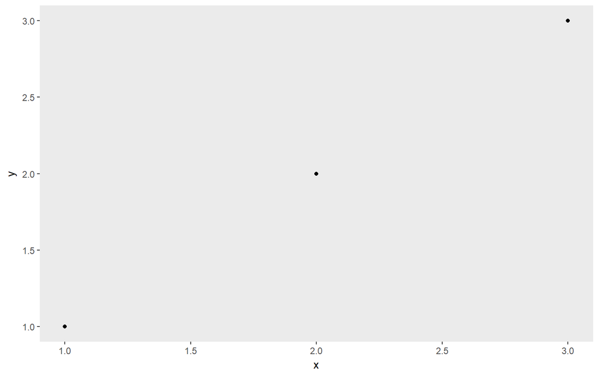

```r
last_plot() + theme(panel.grid.major = element_blank())
```

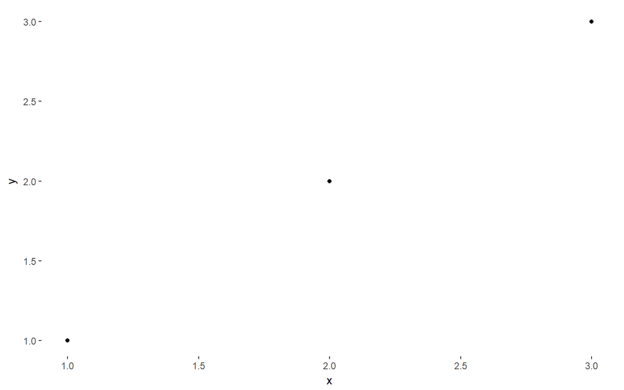

```r
last_plot() + theme(panel.background = element_blank())
```

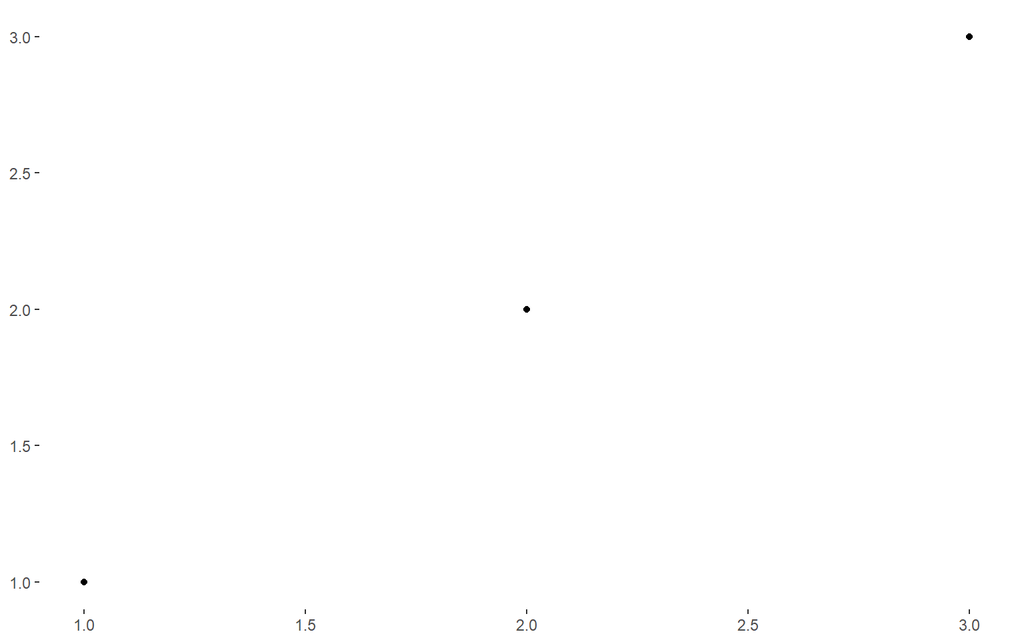

```r
last_plot() + theme(
  axis.title.x = element_blank(),
  axis.title.y = element_blank()
)
```

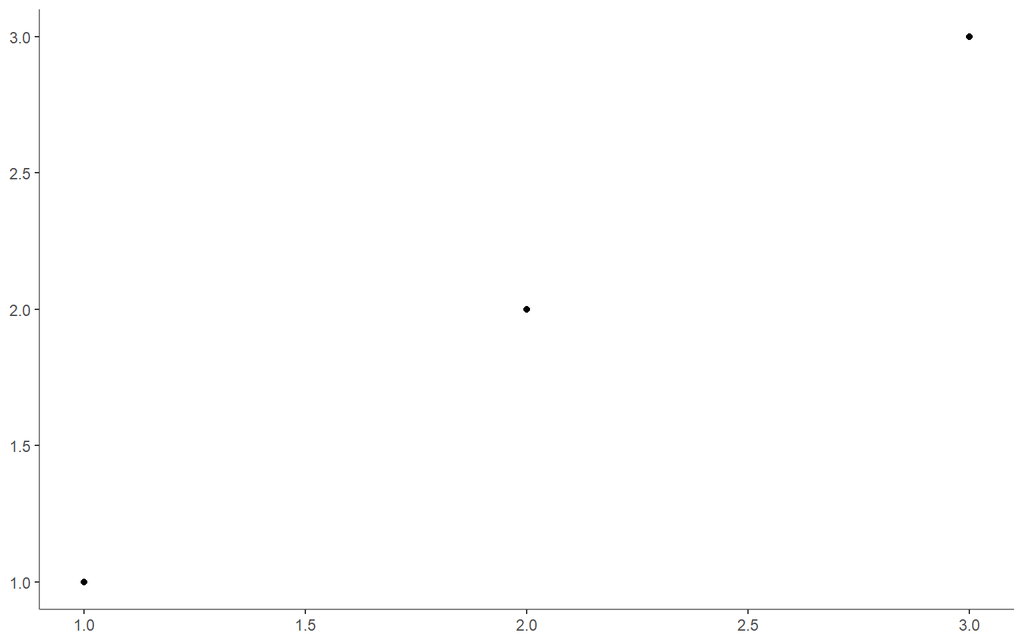

```r
last_plot() + theme(axis.line = element_line(colour = "grey50"))
```

- 그리드 단위를 설정하는 몇가지 다른 세팅이 있다. unit(1, “cm”) 또는 unit(0.25, “in”)

모든 미래의 플랏을 위해 테마 성분을 수정하기 위해 `theme_update()`를 사용해라. 이것은 이전 테마 세팅을 불러오고 본래의 매개변수를 쉽게 복구할 수 있다.

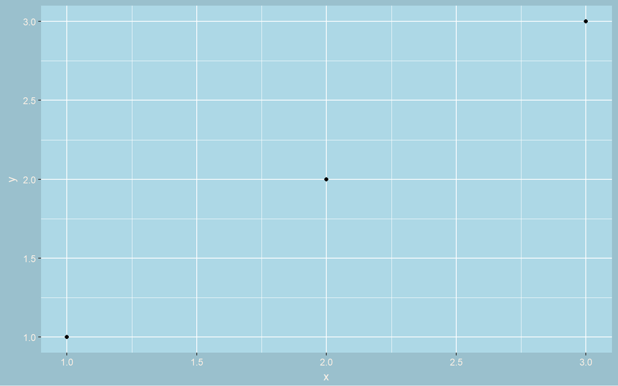

```r
old_theme <- theme_update(
  plot.background = element_rect(fill = "lightblue3", colour = NA),
  panel.background = element_rect(fill = "lightblue", colour = NA),
  axis.text = element_text(colour = "linen"),
  axis.title = element_text(colour = "linen")
)
base
```

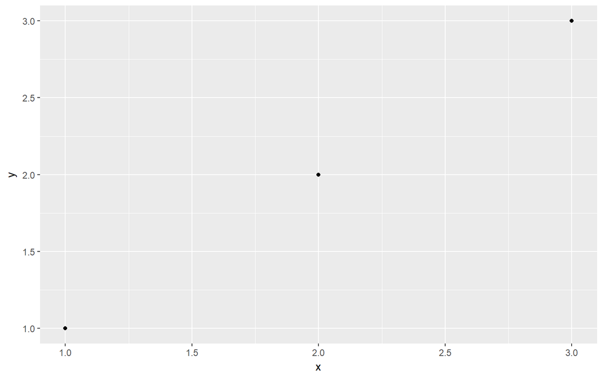

```r
theme_set(old_theme)
base
```

# 2 Theme Elements

plot, axis, legend, panel and facet

## 2.1 Plot Elements

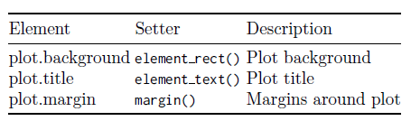

plot.backgorund는 플랏의 모든 것들의 기저를 이루는 사각형을 그린다. 다른 시스템에 플랏을 보낼 때 배경이 투명하도록 fill = NA를 설정할 수 있다. 마찬가지로, 이미 margin을 가지고 있는 시스템에 플랏을 끼워넣는다면 내장되어있는 여백을 제거할 수 있다. 약간의 여백은 여전히 필요하다.

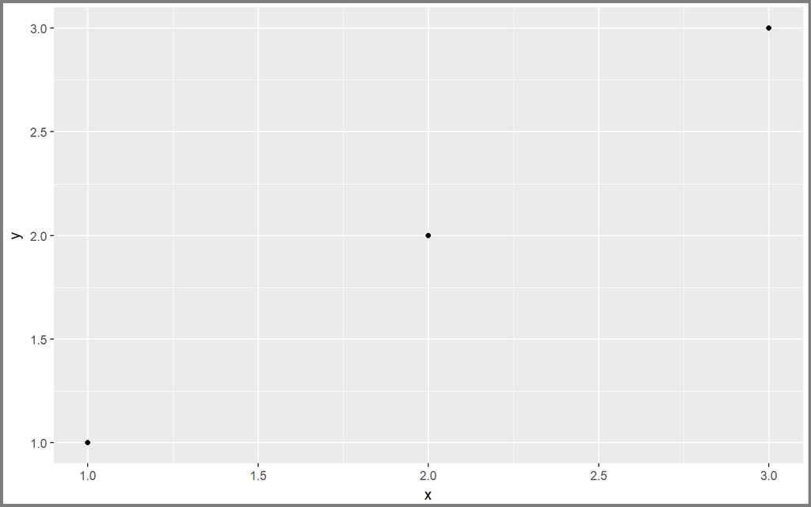

```r
base + theme(plot.background = element_rect(colour = "grey50", size = 2))
```

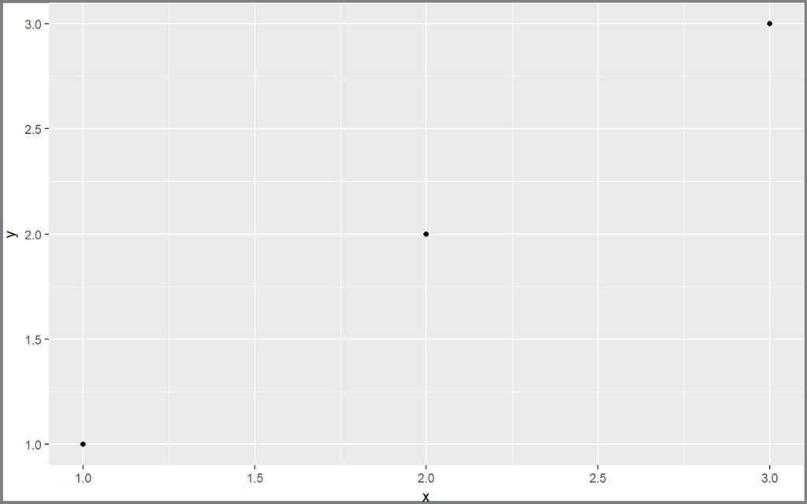

```r
base + theme(
  plot.background = element_rect(colour = "grey50", size = 2),
  plot.margin = margin(2, 2, 2, 2)
)
```

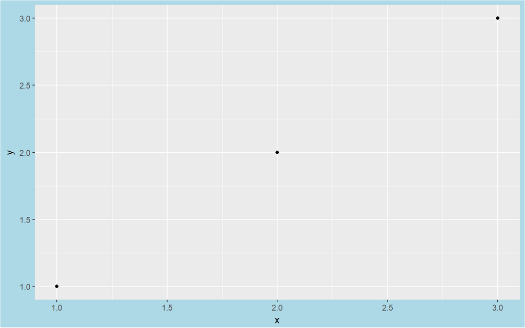

```r
base + theme(plot.background = element_rect(fill = "lightblue"))
```

## 2.2 Axis Elements

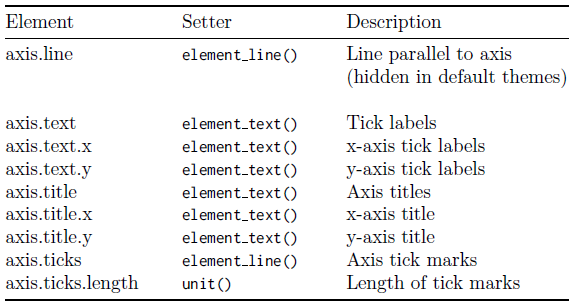

axis.text (and axis. title)은 세가지 형태에서 온다.:axis.text, axis.text.x and axis.text.y. 두 축을 모두 수정하고 싶다면 첫번째 형태를 사용하라.

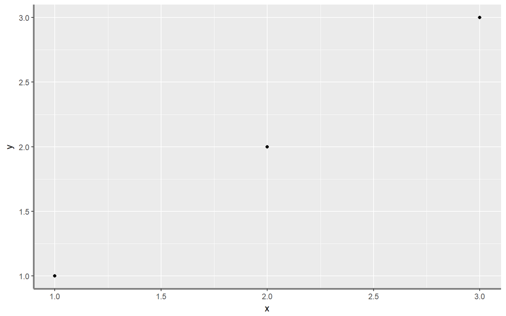

```r
df <- data.frame(x = 1:3, y = 1:3)
base <- ggplot(df, aes(x, y)) + geom_point()

# Accentuate the axes
base + theme(axis.line = element_line(colour = "grey50", size = 1))
```

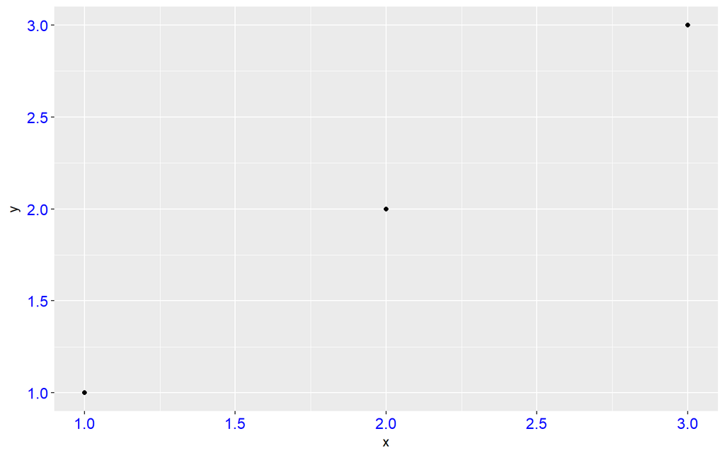

```r
# Style both x and y axis labels
base + theme(axis.text = element_text(color = "blue", size = 12))
```

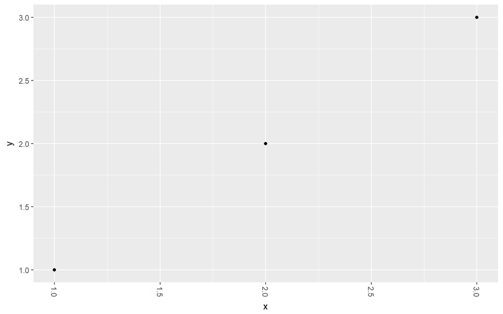

```r
# Useful for long labels
base + theme(axis.text.x = element_text(angle = -90, vjust = 0.5))
```

가장 흔한 조정은 x축 레이블을 오버래핑을 방지하기 위하여 회전시키는 것이다. 음수 각도가 보기 좋다. `hjust = 0` `vjust = 1`을 설정하라.

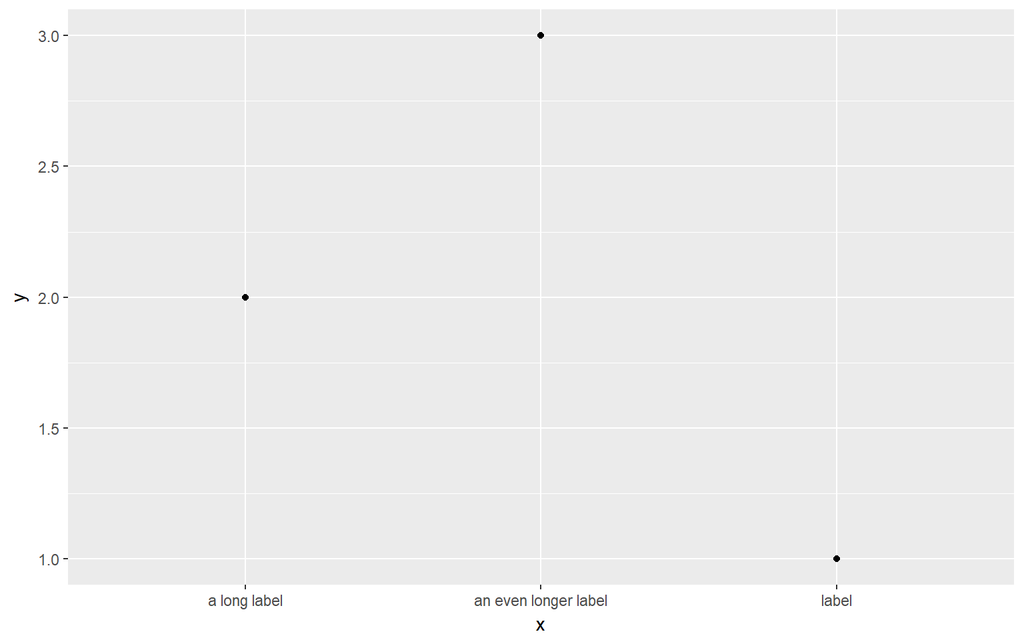

```r
df <- data.frame(
  x = c("label", "a long label", "an even longer label"),
  y = 1:3
)
base <- ggplot(df, aes(x, y)) + geom_point()
base
```

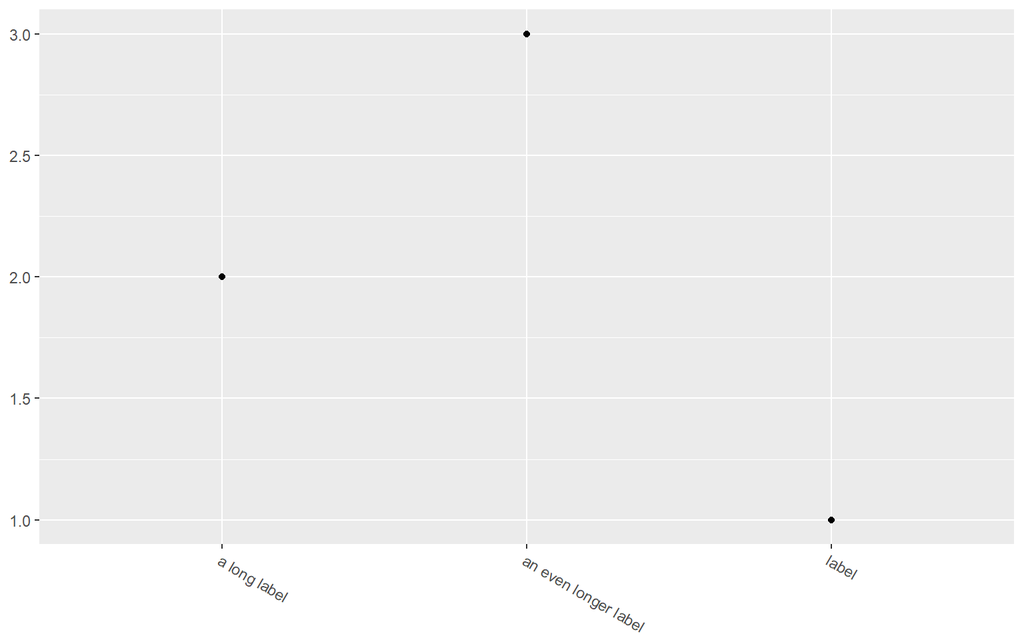

```r
base +
  theme(axis.text.x = element_text(angle = -30, vjust = 1, hjust = 0)) +
  xlab(NULL) +
  ylab(NULL)
```